# Abalone Aggregations

## Data Description

Black abalone (Haliotis cracherodii) are an ecologically and culturally important species found in the rocky intertidal, that have experienced severe population declines due to overharvesting and predation. Aggregation behavior is common in these species to increase fitness and survival in low population densities, yet little is known about what habitat features facilitate viable aggregation sizes.

The projects in Marine Ecology Course at CSU- Monterey Bay conducted invertebrate swaths and quadrat percent coverage data collected along transects from five rocky intertidal sites along the bay. Historic data spanning from 2002 to 2025 was used to asses environmental drivers of black abalone aggregations.

Aggregations were categorized “successful” if they contained four or more individuals as this was stated within existing literature to contribute to reproductive success. Competitive purple sea urchin (Strongylocentrotus purpuratus) densities was measured to assess their influence on abalone aggregation sizes.

## Data Cleaning

The amalgamation of data from 2002 to 2025 created challenges in data uniformity. Site, Species, and excess variables were cleaned ensuring comparisons between sites surveys were possible in all years of surveying.

We determined abalone aggregation sizes as the sum of abalones within a meter position of each other along an individual transect. An aggregations size variable was created by matching the site, date, transect number,and position (rounded to the nearest meter) of each abalone surveyed. Viable abalone aggregation presence was assessed creating a binary presence variable for —aggregations with more than four abalones considered as “yes” having aggregations present, while aggregations with fewer than four abalones considered as “no” viable aggregation present.

Urchin density was calculated as the number of urchins witnessed per transect divided by the area of the transect.To determining transect area the transect lengths recorded were multiplied by 2 for 1 meter swaths conducted on each side of the transects (following the parameters set by researchers).

## Abalone Presence at Sites

The proportion of abalone aggregations at each survey site are expressed with aggregations being the presence of abalone within a meter position of each other along the transects. Aggregations, or groupings of abalone, were categorized as either 4 or more abalone or fewer than 4 abalone. Previous studies have found that aggregations of at least 4 abalones are needed to have a beneficial impact on survival.

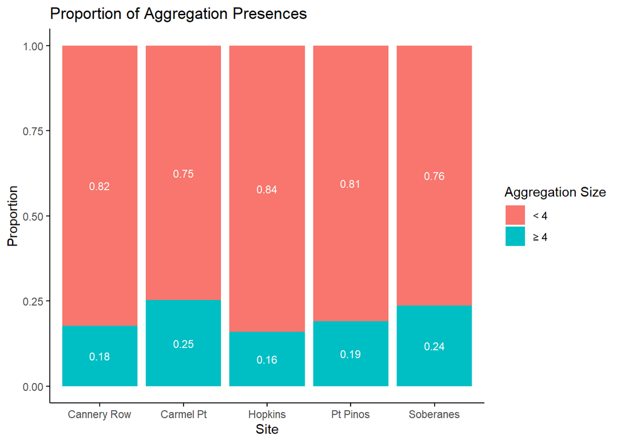

Of 1,972 abalones found, 115 were found at Cannery Row, 966 were found at Carmel Point, 210 were found at Hopkins Marine Station, 328 were found at Point Pinos, and 353 were found at Soberanes.

## Aggregation Sizes with Competition

Purple sea urchin density (m^2) compared to abalone aggregation sizes, as the count of abalone within the aggregation. Distinct colors represent Cannery Row, Carmel Pt, Hopkins, Pt Pinos, and Soberanes survey sites along the Monterey Peninsula. There does not seem to be a strong relationship between sea urchin density and abalone aggregation size although a slight negative trend seems possible. A negative relationship between aggregation sizes and purple urchin density would make sense as both of these organisms compete for the same food and habitat. Therefore with increasing urchin densities this could be outcompeting already vulnerable abalone populations.

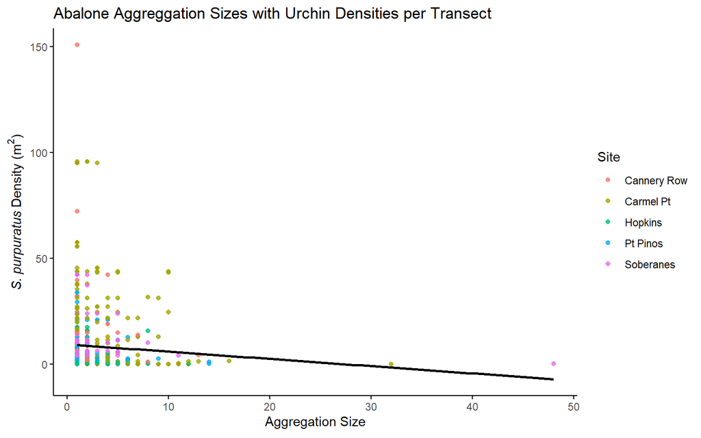

Aggregation sizes and density were only considered if they appeared on corresponding dates and transects, with 347 comparisons modeled.There is not a strong relationship between sea urchin density and abalone aggregation size (p-value: 0.091, Adjusted R-squared: 0.003)

Across all survey sites, aggregations with fewer than 4 abalone were more common than those with 4 or more.This aligns with expectations given the threatened status of the Black Abalone species. Notably, Carmel Point and Soberanes had greater proportions of successful aggregations (4 or more abalone) compared to Cannery Row, Point Pinos, and Hopkins. Additionally, no conclusive relationship between urchin densities with the aggregation size of abalone, either overall or by site was noted.